# 課題

#### (1) K= 1で,T= 1;3;5 [s]の3通りの一次システムの時間応答をPythonで重ねてプロットせよ

- 横軸の範囲は0 sから20 sで100点
- グリッド線あり，凡例あり("T=1", "T=3", "T=5")，軸ラベルあり("t [s]", "y")
- T= 1：青実線，T= 3：緑破線，T= 5：赤一点鎖線

```python
import numpy as np
import matplotlib.pyplot as plt
```

```python
from control.matlab import *
```

```python
n = [1]

d1 = [1, 1]
P1 = tf(n, d1)

d2 = [3, 1]
P2 = tf(n, d2)

d3 = [5, 1]
P3 = tf(n, d3)
```

```python
t = np.linspace(0, 20, 100)
```

```python
y1, t = step(P1, t)
y2, t = step(P2, t)
y3, t = step(P3, t)
```

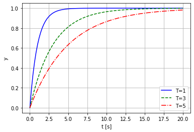

```python
plt.plot(t, y1, label="T=1", color="blue")
plt.plot(t, y2, label="T=3", color="green", linestyle="--")
plt.plot(t, y3, label="T=5", color="red", linestyle="-.")
plt.xlabel("t [s]")
plt.ylabel("y")
plt.grid()
plt.legend()
plt.show()
```

#### (2) プロットしたグラフをもとに一次システムにおける時定数Tの意味を簡単に述べよ（もちろん厳密に述べてもよい）

時定数Tは，過渡状態での変化の速さを表す量であり，時定数が大きいほど変化する速さ（定常状態に達するまでの時間）は遅くなる

#### (3) 電気回路のRC直列回路は時定数RCの一次システムであることが知られている。収束を早めるためには抵抗Rや静電容量Cをどうすればよいだろうか

時定数RCが大きくなるほど定常状態に達するまでの時間が遅くなるため，抵抗Rや静電容量Ｃを小さくすれば収束が早まる